# RepData PeerAssessment1

## usage packages

```r
library(RColorBrewer)
library(dplyr)
```

```r
library(ggplot2)
```

## Loading and preprocessing the data

### unzip the directory

It’s necessary unzip the file and get the file, then we do a review of variables

```r
if (!file.exists('activity.csv')) {
  unzip(zipfile = "repdata_data_activity.zip")
}
activity<-read.csv('activity.csv')
str(activity)
```

```
## 'data.frame':    17568 obs. of  3 variables:
##  $ steps   : int  NA NA NA NA NA NA NA NA NA NA ...
##  $ date    : chr  "2012-10-01" "2012-10-01" "2012-10-01" "2012-10-01" ...
##  $ interval: int  0 5 10 15 20 25 30 35 40 45 ...
```

## What is mean total number of steps taken per day?

### Histogram of the total number of steps taken each day

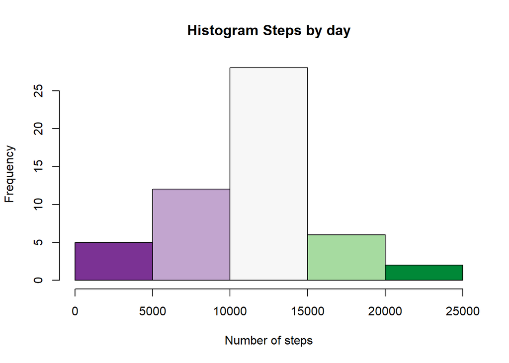

```r
sumday<-tapply(activity$steps,activity$date,sum)
hist(sumday,main = "Histogram Steps by day",xlab = "Number of steps",
     col = brewer.pal(5,"PRGn"))
```

### Mean and Median

```r
meanpday <-as.integer(mean(sumday,na.rm=T))
medianpday <-median(sumday,na.rm=T)
```

The individual take **10766** of mean steps per day and his median per day was of **10765** steps.

## Average daily activity pattern

### Time Series plot 5-minutes interval & averaged across all days

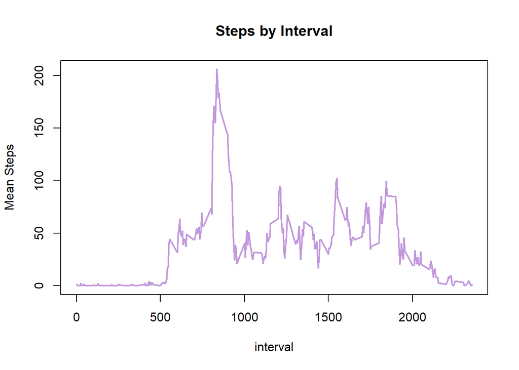

```r
mstep<-aggregate(activity$steps ~ activity$interval,FUN = "mean")
plot(mstep,type="l",col="#c299dc",main="Steps by Interval",
     xlab="interval", ylab="Mean Steps",lwd="2")
```

```r
maxi<-max(mstep$`activity$steps`,na.rm = T)
maxI<-mstep[mstep$`activity$steps`==maxi,1]
```

The max of steps in a interval in mean is **206.1698113** and the interval is the **835**

## Missing Values

```r
MV<-is.na(activity$steps)
MissingValues<-sum(MV)
```

The number of the missing values in the dataset is **2304**

It’s necessary complete the dataset, then we use mstep created above for this purpose

```r
activityComplete<-cbind(activity,MV)
activityComplete$steps<-ifelse(activityComplete$MV==1,
       activityComplete$steps<-as.integer(mstep[mstep$`activity$interval` ==
                                             activityComplete$interval,2]),
       activity$steps)
activityComplete <- select(activityComplete,-"MV")
```

[figure not shown]

```r
sumdayC<-tapply(activityComplete$steps,activityComplete$date,sum)
hist(sumday,main = "Histogram Steps by day Complete Dataset",xlab = "Number of steps",
     col = brewer.pal(5,"PRGn"))
```

### Mean and Median

```r
meanpdayC<- as.integer(mean(sumdayC,na.rm=T))
medianpdayC<- as.integer(median(sumdayC,na.rm=T))
```

The individual take **10763** of mean steps per day and his median per day was of **10703** steps.

The impact of imputing missing data in the dataset is a more conffidence DB, but the change is so little because the differences are **3** in the mean and **62** in the median.

## Weekdays vs Weekends

It’s used the days of the week for separate between weekdays and weekends

```r
activityComplete$day<-as.numeric(strftime(as.Date(activityComplete$date,"%Y-%m-%d"),"%u"))
activityComplete$day<-as.factor(ifelse(activityComplete$day<=5,
       "weekday",
       "Weekend"))
(table(activityComplete$day))
```

```
##
## weekday Weekend
##   12960    4608
```

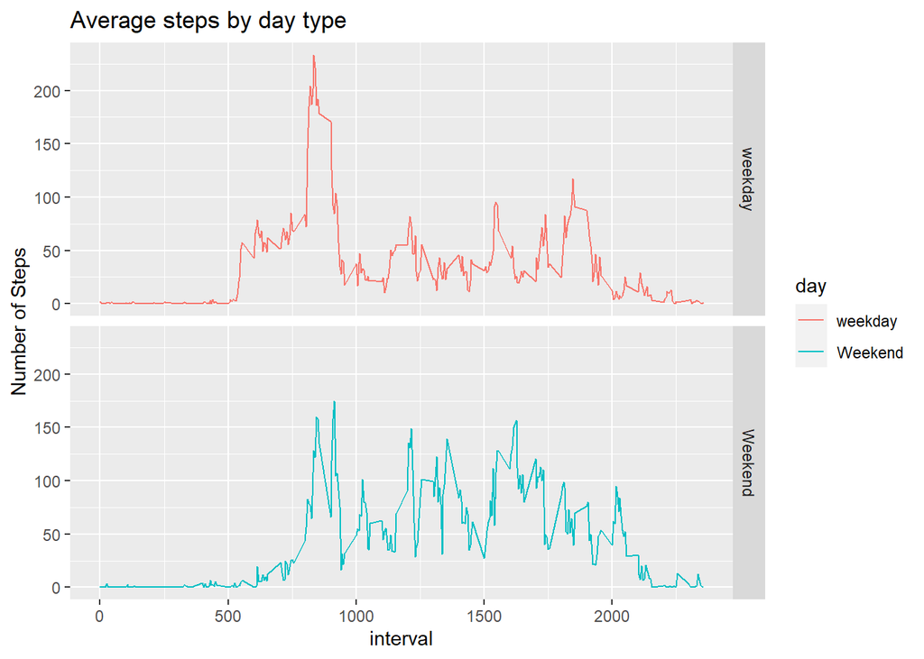

```r
mstepW<-aggregate(steps ~ interval +
                        day,activityComplete,FUN = "mean")

ggplot(mstepW,aes(interval,steps, col=day)) + geom_line() +
        facet_grid(day ~ .) + labs(title = "Average steps by day type",
                                   y = "Number of Steps",
                                   x = "interval")
```